# Tutorial 01: Introducción

Grace Smith-Vidaurre

2023-12-27

## Información sobre esta traducción

Este tutorial fue traducido al español por Grace Smith-Vidaurre y editado por Tania Molina, siguiendo las [convenciones de traducción de los Carpentries](https://github.com/Carpentries-ES/board/blob/master/Convenciones_Traduccion.md), incluyendo usar el género femenino por defecto. Si encuentras errores de ortografía que impiden tu habilidad de completar los tutoriales, por favor reporta los errores de ortografía a GitHub usando los pasos en este primer tutorial para reportar un “Issue”.

## Resumen del tutorial y objetivos de aprendizaje

En este primer tutorial, vas a leer sobre el programa RStudio, aprender cómo crear una versión local de el repositorio de ABISSMAL en GitHub, y aprender más sobre el `pipeline` de análisis de datos en ABISSMAL. En este tutorial vas a aprender cómo:

1. Configurar tu sesión de RStudio
2. Crear una versión local de un repositorio de GitHub
3. Usar ABISSMAL para procesar y analizar datos
4. Solucionar problemas con tu código usando recursos en línea
5. Reportar problemas de código a GitHub

Hay muchas formas de hacer una sola tarea o solucionar un problema en R, y deberías de mantener esto en mente mientras completas estos tutoriales. En cada tutorial, vas a aprender diferentes ejemplos sobre cómo manejar ciertas tares o solucionar problemas específicas con código, pero estos ejemplos no son un resumen exhaustivo de cómo manejar cada tarea ni cómo solucionar cada problema. Más bien recomiendo que usas estos tutoriales como una oportunidad para practicar cómo usar tus habilidades de escribir código en un contexto biológico.

## Configurar tu sesión de RStudio

Si nunca has usado R, un lenguaje de programación para análisis estadísticos, ni RStudio, una interfaz gráfica de usuario, recomiendo revisar el tutorial [R for Reproducible Scientific Analysis](https://swcarpentry.github.io/r-novice-gapminder-es/) de [Software Carpentry](https://software-carpentry.org/).

Cuando hayas instalado R y RStudio en tu computadora, puedes hacer clic en el ícono de RStudio para abrir el programa. La configuración predeterminada de los paneles de RStudio se debería de ver algo así, aunque el color de fondo puede ser diferente:

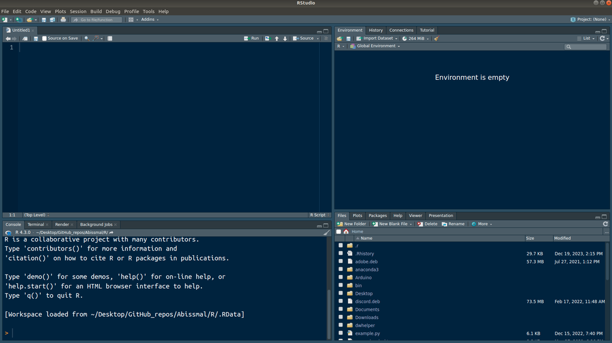

Con esta configuración de paneles es difícil de ver el código que escribes y guardas en archivos físicos en el panel de la fuente, tanto como el resultado de ese código en el panel de la consola. Puedes reconfigurar los paneles para que el panel de la fuente esté al lado izquierdo del panel de la consola, y así será más fácil de ver los resultados de tu código inmediatamente. Puedes seguir los siguientes pasos para reconfigurar los paneles en RStudio:

- Selecciona la opción “Tools” en el menú
- Selecciona la opción “Global Options” en el menú desplegable que sale en “Tools”
- Se va a abrir otra ventana con opciones. Selecciona la opción “Pane Layout” a la izquierda
- Usa el menú desplegable para seleccionar “Source” como el panel en la primera fila y al lado izquierdo, y selecciona “Console” como el panel que ocupará la siguiente parte de la primera fila de paneles a tu mano derecha
- Puedes seleccionar “Apply” para aplicar estos cambios y luego “Ok” para salir de esta ventana

Tu configuración de paneles en RStudio ahora se debería de ver así:

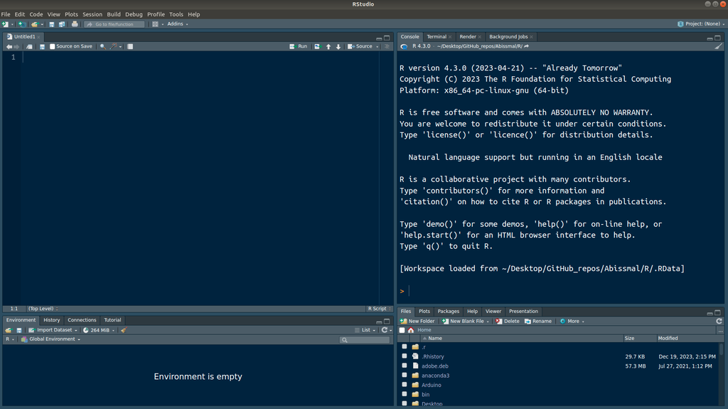

Otro cambio que puedes implementar en tu configuración de RStudio es el retorno automático, para no tener que hacer scroll a tu derecha cada vez que quieres leer una línea completa de texto o código. Para implementar este cambio, puedes ir a “Tools”, luego “Global Options”, seleccionar “Code”, y seleccionar la caja para la opción “Soft-wrap R source files”, luego hacer clic en “Apply” y “Ok”.

También puedes cambiar el tamaño de la fuente del texto y código que escribes, tanto como el color de texto y código, y el color de fondo de tu ventana de RStudio. Después de seleccionar “Tools” y “Global Options”, puedes seleccionar “Appearance” para ver diferentes opciones.

## Crear una versión local de un repositorio de GitHub

Si nunca has usado GitHub, recomiendo bajar el programa [GitHub Desktop](https://docs.github.com/es/desktop). Este programa es una interfaz gráfica de usuario para el plataforma de GitHub, que provee un sistema de control de versiones. Vamos a seguir unos pasos para crear una versión local del repositorio de ABISSMAL que está en GitHub para que puedas acceder las funciones de R de ABISSMAL en tu propia computadora. Si ya sabes cómo usar GitHub y cómo usar Git en el terminal, puedes seguir las instrucciones que tenemos en el [README de ABISSMAL](https://github.com/lastralab/ABISSMAL).

Cuando hayas instalado GitHub Desktop, puedes:

- Hacer clic en el ícono de GitHub Desktop para abrir el programa
- Abrir tu navegador web e ir al repositorio de ABISSMAL en GitHub: https://github.com/lastralab/ABISSMAL
- Hacer clic en el botón verde de “Code” y copiar la URL debajo de la opción “HTTPS” en el menú desplegable
- Ir al menú de GitHub Desktop y seleccionar “File”
- Seleccionar “Clone repository”
- Seleccionar la pestaña “URL”
- Pegar la URL de ABISSMAL que copiaste de GitHub en la caja que pide un “Repository URL or GitHub username and repository”
- Revisar que el directorio en la caja “Local path” es la ubicación en tu computadora donde quieres instalar el repositorio de ABISSMAL. Por ejemplo, si “Local path” es “/home/User/Desktop/ABISSMAL”, el repositorio de ABISSMAL se instalará directamente en tu Desktop
- Seleccionar “Clone” cuando estés lista para crear una versión local del repositorio de ABISSMAL en tu computadora

Cuando el repositorio se haya instalado en tu computadora, deberías de poder ver el siguiente directorio y una lista de archivos adentro de una carpeta llamada “ABISSMAL”:

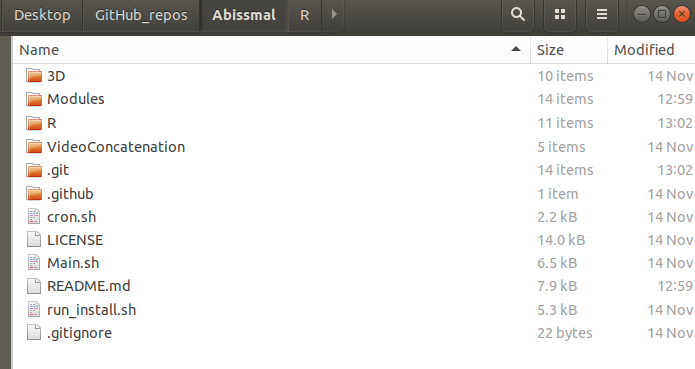

Los archivos que vamos a usar en los siguientes tutoriales están adentro de la carpeta “R”. Esta carpeta contiene 6 archivos de R (extensión “.R”), un archivo README que contiene más información sobre cada archivo de R, y carpetas con los tutoriales en formato RMarkdown (extensión “.Rmd”), y también código para pruebas unitarias automatizadas.

## Procesar y analizar datos con ABISSMAL

ABISSMAL provee 5 funciones diferentes de R para procesar y analizar datos, y describimos estas funciones en más detalle abajo, en el orden general en que se deberían de usar. Puedes encontrar más información detallada sobre estas funciones en el archivo README de la carpeta “R”, y también en el manuscrito asociado con ABISSMAL:

1. `combine_raw_data` automáticamente combina hojas de cálculo de los datos originales que fueron colectados por día y los guarda en una sola hoja de cálculo a través de todos los días de colección de datos. Esta concatenación de datos se realiza por cada tipo de sensor, por ejemplo, los sensores de rayos infrarrojo o una cámara de infrarrojo, y no cambia ni reemplaza los datos originales. Esta función puede usar datos de los sensores de RFID (“radio frequency identification”), los sensores infrarrojo, la cámara, o el sensor de temperatura de ABISSMAL. Las siguientes funciones no aceptan datos de temperatura
2. `detect_perching_events` toma como entrada los resultados de `combine_raw_data` y detecta grupos de detecciones que ocurrieron cerca en el tiempo como eventos de posar. Estos eventos de posa representan periodos de tiempo cuando un individuo estuvo posado en la antena de RFID (como percha) situado en la entrada del contenedor de nido. La función usa datos de los sensores ubicados en la entrada del contenedor (RFID o los sensores de infrarrojo) y devuelve una hoja de cálculo de las coordenadas temporales de los eventos de posar inferidos
3. `preprocess_detections` usa como entrada los resultados de `combine_raw_data` y remueve detecciones que ocurrieron muy cerca en el tiempo. Esta función devuelve una hoja de cálculo de datos pre-procesados por tipo de sensor, y en cada hoja de cálculo, las detecciones consecutivas deberían de estar separadas por un umbral temporal predeterminado o más. Por ejemplo, cuando usas un umbral temporal de 1 segundo para filtrar las detecciones originales, solo una detección puede ocurrir por segundo en los datos procesados
4. `detect_clusters` usa como entrada los resultados de `preprocess_detections` obtenidos con dos o más tipos de sensores. La función identifica detecciones a través de dos o más tipos de sensores que ocurrieron cerca en el tiempo, y devuelve información temporal y metadatos sobre cada grupo o `cluster` (cúmulo). Cada `cluster` de detecciones representa un evento discreto de movimiento de un individuo o más que un individuo
5. `score_clusters` usa como entrada los resultados de `detect_clusters`. Esta función también puede usar los resultados de `detect_perching_events` para integrar los eventos de posar que fueron identificados en los datos originales de RFID o los sensores de infrarrojo, y puede usar los resultados de `preprocess_detections` para integrar los eventos de grabación de vídeos que no fueron incluidos en los `clusters` detectados por `detect_clusters`. Esta función hace inferencias de comportamiento de los eventos de movimiento, incluyendo la dirección de movimiento, la magnitud de movimiento, la identidad de individuo (cuando datos de RFID se encontraron en un `cluster`), y en donde ocurrió el inicio de la secuencia de movimiento (en la entrada o adentro del contenedor de nido). La función devuelve una hoja de cálculo de inferencias de comportamiento y otros metadatos sobre cada evento de movimiento, y estos resultados se pueden usar para visualizaciones y análisis estadísticos.

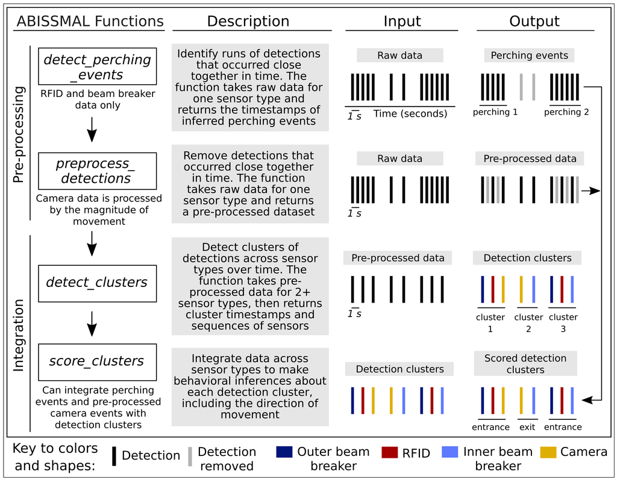

* Esta figura es de Smith-Vidaurre, G., Molina, T., Jarvis, E.D., and E.A. Hobson. 2023. Automated tracking of avian parental care. EcoEvoRxiv preprint.

## Solucionar errores en línea

Mientras escribes y ejecutas código encontrarás errores que a veces pueden ser frustrantes. Experimentar y solucionar los errores que te salen es una parte muy importante de tu proceso de aprendizaje en R (u otros lenguajes de programación). Los errores surgen por diferentes razones, incluyendo errores de mecanografía mientras escribes código, problemas con las versiones de paquetes externos de R que instalaste, o posiblemente por necesitar funciones de paquetes que no has instalado en tu computadora. Los errores a veces pueden surgir por problemas con las funciones de ABISSMAL que usarás en los siguientes tutoriales, o por errores con el código en los tutoriales mismos.

Cuando experimentas un error con tu código, es importante intentar solucionar el error independientemente antes de suponer que el error nació de errores de las funciones de ABISSMAL o los tutoriales. Hay muchos recursos en línea que puedes usar para solucionar errores comunes o inusuales en R. Puedes empezar con copiar y pegar el mensaje de error que ves en tu consola en un buscador, y así deberías de ver varias opciones de foros públicos dónde otras personas han preguntado por y solucionado errores similares. También deberías de poder de usar herramientas de IA generativo como ChatGPT para buscar errores de mecanografía u otros problemas con tu código. Otra opción útil es leer la documentación de R para investigar si el error que ves esta relacionado con un paquete o una función que puede ser una dependencia de ABISSMAL.

Ya cuando hayas investigado cuidadosamente un error, y estas segura que el error no se debe a un error de mecanografía o problemas con la estructura de tus datos, luego puedes considerar si el error se debe a un problema con las funciones de ABISSMAL o los tutoriales mismos, y puedes reportar el error a las desarolladoras de ABISSMAL en GitHub (ver la siguiente sección).

## Reportar errores en GitHub

Es posible que encuentres errores mientras trabajas en cada tutorial, incluyendo errores con código que no ejecuta, o código que devuelve resultados incorrectos. Estos errores pueden manifestar desde las funciones de ABISSMAL o con el código de algún tutorial. Si encuentras un error en una función de ABISSMAL, puedes crear un “Issue” (un asunto o problema) en el repositorio de GitHub. Para crear un “Issue” nuevo, puedes seleccionar “New Issue” en la página de [Issues](https://github.com/lastralab/ABISSMAL/issues) en el repositorio de ABISSMAL, y seguir las instrucciones en el esquema del “Issue” nuevo para añadir la información que las desarrolladoras necesitan para trabajar efectivamente en el error. También puedes añadir la etiqueta de “bug” (o error) a tu “Issue”. Si encuentras un error con los tutoriales puedes crear un “Issue” usando los mismos pasos, y deberías de clarificar que el error está relacionado al código de algún tutorial en particular.

En el siguiente tutorial, vamos a crear datos simulados de movimiento de animales para aprender cómo usar las cinco funciones primarias de ABISSMAL.